# Crowdfunding, R-project

Задачи:

1. Посмотреть, есть ли корреляция между объемом текста и успехом сбора
2. Посмотреть наиболее частотные слова в подзаголовках и их распределение относительно успешности сборов.

## Структура датасета

```
## 'data.frame':    1704 obs. of  15 variables:
##  $ X          : int  0 1 2 3 4 5 6 7 8 9 ...
##  $ Title      : Factor w/ 1624 levels "\" Я - другая\"",..: 936 832 833 27 534 704 1134 1315 239 1116 ...
##  $ Briefly    : Factor w/ 1615 levels " Сбор средств на реабилитацию в РЦ \"Любовь Ангела\", город Новосибирск.",..: 1371 1244 1276 1530 7 985 1557 1348 638 1566 ...
##  $ Description: Factor w/ 1734 levels "                                     ",..: 881 1094 531 1057 1440 1373 1183 242 892 233 ...
##  $ Result     : int  76100 711665 236257 95300 42550 1244216 104500 11010 65601 24000 ...
##  $ Goal       : int  10000 150000 50000 29395 15000 537133 46365 5000 30000 11000 ...
##  $ Donations  : int  67 470 202 170 87 50 217 13 84 37 ...
##  $ LengthZn   : int  1134 1749 1693 2138 1765 2510 2548 1946 1371 1648 ...
##  $ LengthWd   : int  193 300 275 383 340 382 451 338 252 283 ...
##  $ NumSent    : int  17 21 20 33 24 24 26 31 24 14 ...
##  $ NumSentNLTK: int  17 22 20 24 23 16 24 19 24 15 ...
##  $ Started    : Factor w/ 974 levels "1 Apr 2015","1 Apr 2016",..: 97 17 196 444 969 418 229 702 784 244 ...
##  $ Finished   : Factor w/ 1070 levels "1 Apr 2014","1 Apr 2016",..: 1062 311 290 481 1011 376 236 858 715 557 ...
##  $ LeadBag    : Factor w/ 1612 levels "['абилитация', 'реабилитация', 'ребёнок', 'инвалид', 'применение', 'метод', 'лечебный', 'педагогика', 'цель', '"| __truncated__,..: 1370 1188 1224 1533 237 871 1561 1339 1572 1573 ...
##  $ DaysLong   : int  59 77 94 59 29 60 30 32 28 7 ...
```

## Длина текстов

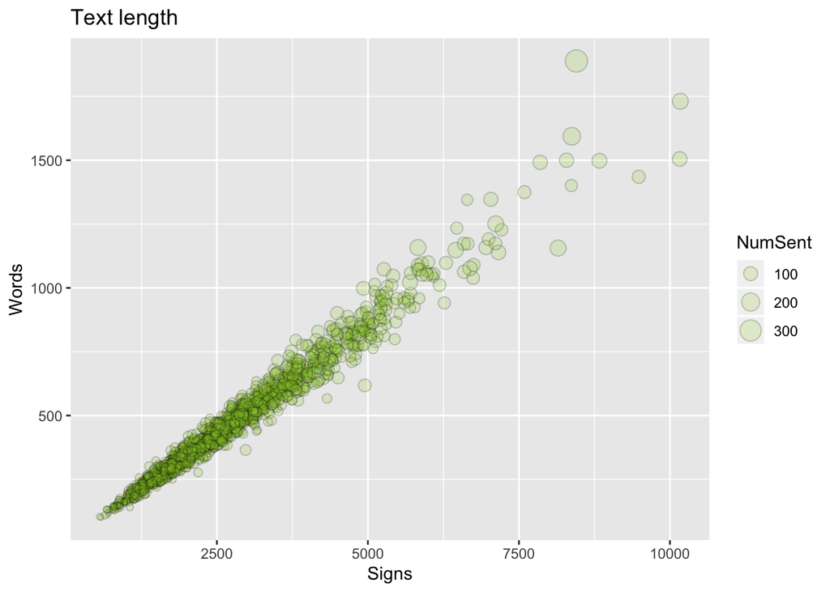

```r
sws <- plset %>%
  select(LengthZn, LengthWd, NumSent)

ggplot(data = sws, aes(x = LengthZn, y = LengthWd)) +
  geom_point(aes(size = NumSent), shape = 21, alpha = 0.2, color = "black", fill = "yellowgreen") +
  labs(title = "Text length", x = "Signs",
       y = "Words")
```

Предскажем количество слов в тексте объемом 1 стандартная страница (правда, без пробелов, т.к. они не считались при сборе датасета):

```r
regr <- lm(LengthWd ~ LengthZn, data = plset)
summary(regr)
```

```
##
## Call:
## lm(formula = LengthWd ~ LengthZn, data = plset)
##
## Residuals:
##     Min      1Q  Median      3Q     Max
## -239.84  -17.44   -0.34   16.92  441.13
##
## Coefficients:
##              Estimate Std. Error t value Pr(>|t|)
## (Intercept) 1.0832665  2.0564037   0.527    0.598
## LengthZn    0.1711774  0.0007075 241.953   <2e-16 ***
## ---
## Signif. codes:  0 '***' 0.001 '**' 0.01 '*' 0.05 '.' 0.1 ' ' 1
##
## Residual standard error: 37.6 on 1702 degrees of freedom
## Multiple R-squared:  0.9717, Adjusted R-squared:  0.9717
## F-statistic: 5.854e+04 on 1 and 1702 DF,  p-value: < 2.2e-16
```

```r
predict(regr, newdata = data.frame(LengthZn = 1800))
```

```
##        1
## 309.2026
```

### Корреляция

Нулевая гипотеза: корреляция между длиной текста, выраженной в знаках, словах и предложениях, близка к нелевой.

```r
cor(words, signs)
```

```
## [1] 0.9857728
```

```r
cor.test(words, signs)
```

```
##
##  Pearson's product-moment correlation
##
## data:  words and signs
## t = 241.95, df = 1702, p-value < 2.2e-16
## alternative hypothesis: true correlation is not equal to 0
## 95 percent confidence interval:
##  0.9843653 0.9870544
## sample estimates:
##       cor
## 0.9857728
```

```r
cor(sents, words)
```

```
## [1] 0.8776929
```

```r
cor.test(words, sents)
```

```
##
##  Pearson's product-moment correlation
##
## data:  words and sents
## t = 75.559, df = 1702, p-value < 2.2e-16
## alternative hypothesis: true correlation is not equal to 0
## 95 percent confidence interval:
##  0.8663131 0.8881621
## sample estimates:
##       cor
## 0.8776929
```

Положительная связь почти “1”. А p-value < 2.2e-16 , т.е. < 0.00000000000000022 -> мы можем отброcить НГ, что связи нет.

Мы увидели, что длина в словах, знаках и предложениях коррелирует -> можем взять одну из переменных как покзатель длины текста, возьмем измерение в словах

### Распределение и статистики переменной words

Проверка на нормальность - график квантиль-квантиль. Это графики, на которых квантили из двух распределений расположены относительно друг друга. If all the points fall approximately along the reference line, we can assume normality.

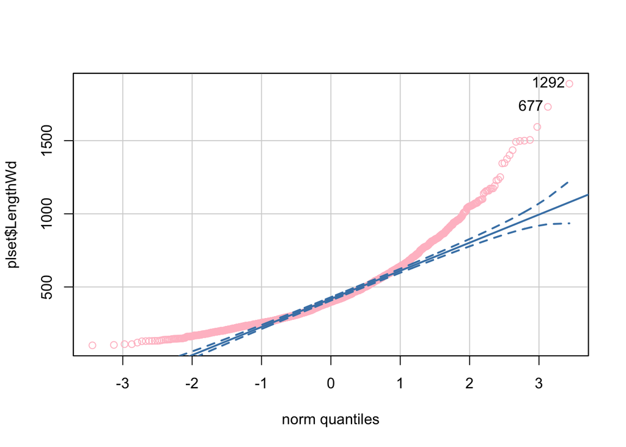

```
## [1] 1292  677
```

```r
qqPlot(plset$LengthWd, col="pink", col.lines="steelblue")
```

### Ассиметрия данных

Если асимметрия значительно отличается от нуля, то гипотезу о том, что данные взяты из нормально распределенной генеральной совокупности, следует отвергнуть.

```r
skew(words)
```

```
## [1] 1.595155
```

### Коэффициент эксцесса

Если коэффициент вариации значительно отличается от нуля, то гипотезу о том, что данные взяты из нормально распределенной генеральной совокупности, следует отвергнуть.

```r
kurtosi(words)
```

```
## [1] 3.963273
```

### Тест Шапиро-Уилка

```r
shapiro.test(words)
```

```
##
##  Shapiro-Wilk normality test
##
## data:  words
## W = 0.8844, p-value < 2.2e-16
```

НГ: данные распределены нормально. Получили p-value < 0.05 значит, НГ можно отклонить.

### Гистограмма распределения длин текстов

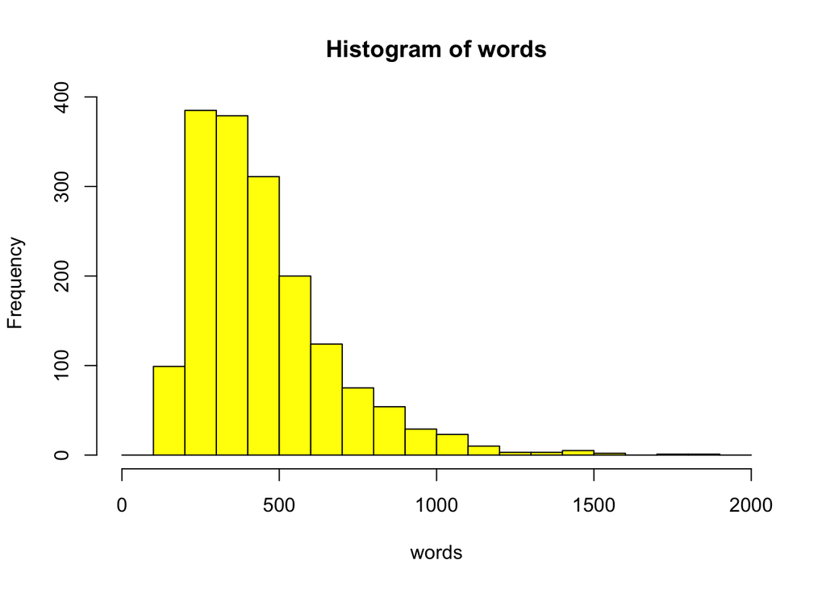

```r
hist(words, breaks = seq(0, 2000, 100), col = "yellow")
```

### Ящик

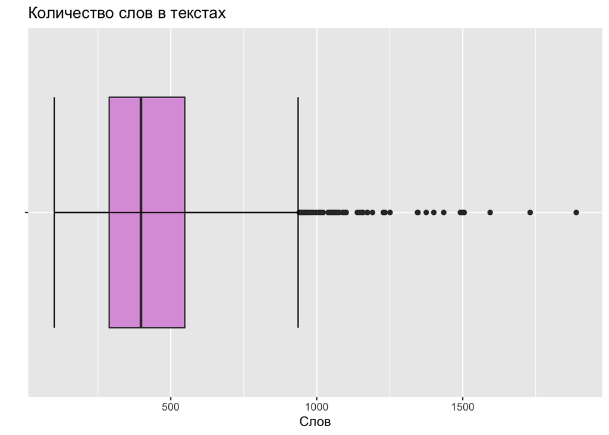

```r
words_df <- plset %>%
  select(LengthWd)

ggplot(data = words_df, aes(x = "", y = LengthWd)) +
  geom_boxplot(fill = "plum") +
  stat_boxplot(geom ="errorbar") +
  xlab("") + ylab("Слов") +
  ggtitle("Количество слов в текстах") +
  coord_flip()
```

Видим, что медиана около 400 слов, 50% текстов - прим. от 300 до 600 слов.

### В цифрах:

```r
psych::describe(words)
```

```
##    vars    n   mean     sd median trimmed   mad min  max range skew kurtosis
## X1    1 1704 447.16 223.64    398  417.51 183.1 101 1889  1788  1.6     3.96
##      se
## X1 5.42
```

## Деньги

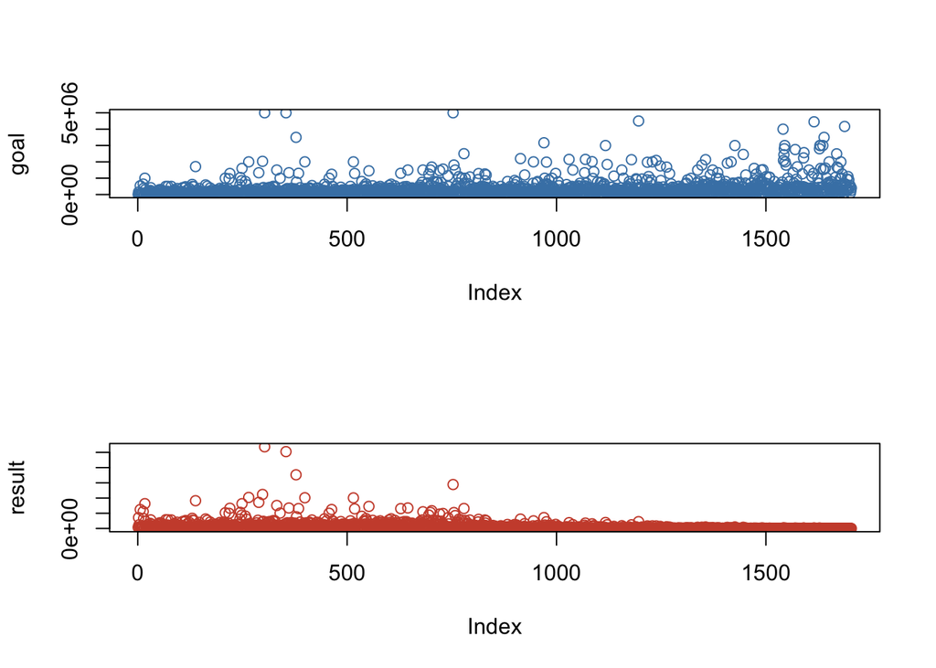

```r
par(mfrow = c(2,1))
plot(goal, col = "steelblue")
plot(result, col = "tomato3")
```

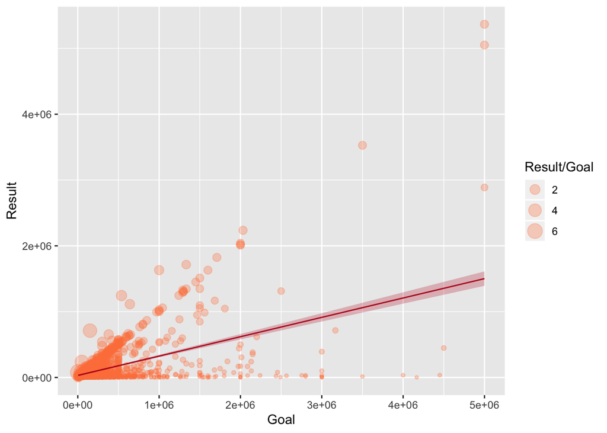

```r
goal_vs_result <- plset %>%
  select(Goal, Result)

ggplot(data = goal_vs_result, aes(x = Goal, y = Result))+
  geom_point(aes(size = Result/Goal), alpha = .3, color = "sienna1")+
  geom_smooth(method = "lm", color = "#BA1820", fill = "#BA1820", size = 0.5, alpha = .25)
```

Цель и итог плохо коррелируют, нужна другая мера.

```r
plset <- plset[plset$DaysLong > 0, ] #иначе дальше деоится на ноль и получается inf

plset <- plset %>%
  mutate(Ratio  = round((Result/Goal)*100, digits = 0)) %>%
  mutate(Ratio)

plset <- plset %>%
  mutate(RubDay  = round(Result/DaysLong)) %>%
  mutate(Ratio)

ratio <- plset$Ratio
rubday <- plset$RubDay

summary(rubday)
```

```
##    Min. 1st Qu.  Median    Mean 3rd Qu.    Max.
##       1     198     788    2536    2455   59382
```

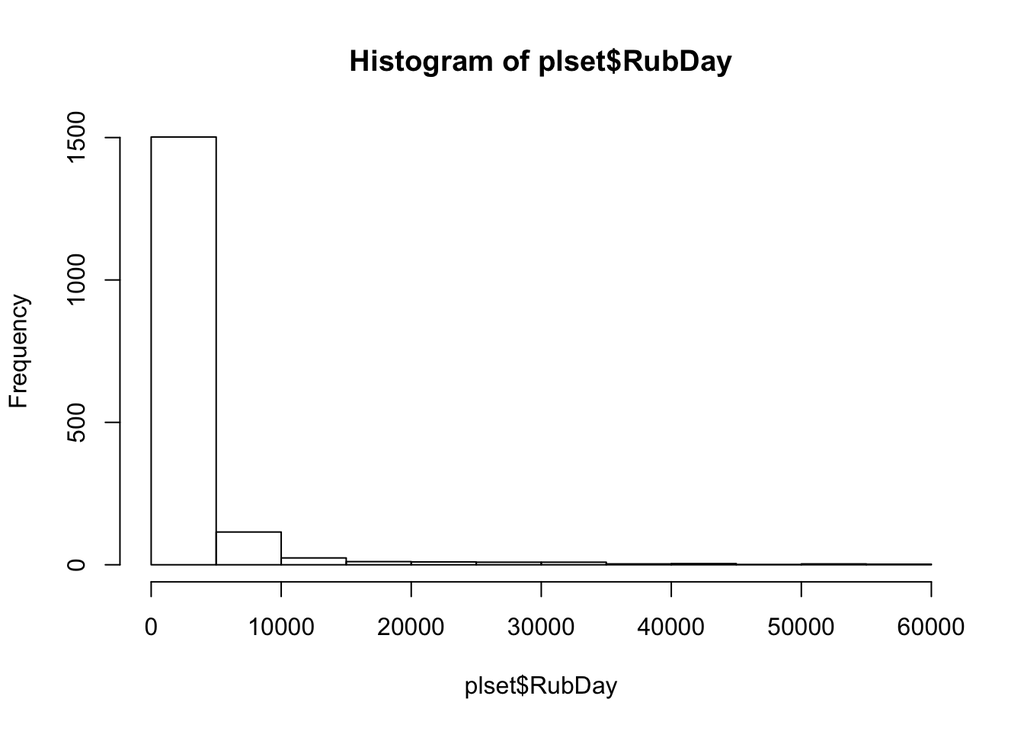

```r
par(mfrow = c(1,1))
hist(plset$RubDay)
```

```r
cor(plset$LengthWd, plset$RubDay)
```

```
## [1] 0.0800974
```

```r
cor.test(plset$LengthWd, plset$RubDay)
```

```
##
##  Pearson's product-moment correlation
##
## data:  plset$LengthWd and plset$RubDay
## t = 3.3044, df = 1691, p-value = 0.0009718
## alternative hypothesis: true correlation is not equal to 0
## 95 percent confidence interval:
##  0.03258128 0.12725228
## sample estimates:
##       cor
## 0.0800974
```

Коэфф. корреляции близок к 0 (0.08), но p-value < 0.05 - > можно усомниться в нулевой гипотезе, что связи нет.

```r
cor(plset$LengthWd, plset$Goal)
```

```
## [1] 0.1624948
```

```r
cor.test(plset$LengthWd, plset$Goal)
```

```
##
##  Pearson's product-moment correlation
##
## data:  plset$LengthWd and plset$Goal
## t = 6.7721, df = 1691, p-value = 1.746e-11
## alternative hypothesis: true correlation is not equal to 0
## 95 percent confidence interval:
##  0.1157504 0.2085210
## sample estimates:
##       cor
## 0.1624948
```

Уже больше, можно предположить, что чем больше денег просит автор, тем многословнее он пытается описать цель сбора.

### Успех по рангам

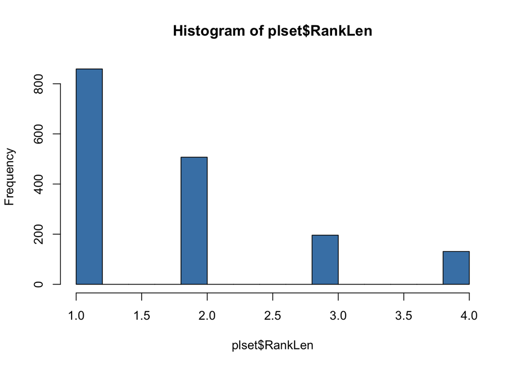

```r
plset <- plset %>%
  mutate(RankS_4 = ifelse(plset$RubDay > 10000, 4, 0)) %>%
  mutate(RankS_3 = ifelse(plset$RubDay >= 5000 & plset$RubDay <= 10000, 3, 0)) %>%
  mutate(RankS_2 = ifelse(plset$RubDay >= 500 & plset$RubDay < 5000, 2, 0)) %>%
  mutate(RankS_1 = ifelse(plset$RubDay < 500, 1, 0)) %>%
  mutate(RankSuccess = RankS_4 + RankS_3 + RankS_2 + RankS_1)

plset <-  plset[ , -which(names(plset) %in% c("RankS_4", "RankS_3", "RankS_2", "RankS_1"))]

plset <- plset %>%
  mutate(L_4 = ifelse(plset$LengthWd > 800, 4, 0)) %>%
  mutate(L_3 = ifelse(plset$LengthWd <= 800 & plset$LengthWd > 600, 3, 0)) %>%
  mutate(L_2 = ifelse(plset$LengthWd <= 600 & plset$LengthWd > 400, 2, 0)) %>%
  mutate(L_1 = ifelse(plset$LengthWd <= 400 & plset$LengthWd > 20, 1, 0)) %>%
  mutate(RankLen = L_1 + L_2 + L_3 + L_4)

plset <-  plset[ , -which(names(plset) %in% c("L_4", "L_3", "L_2", "L_1"))]

#par(mfrow = c(2,1))
hist(plset$RankLen, col = "steelblue")
```

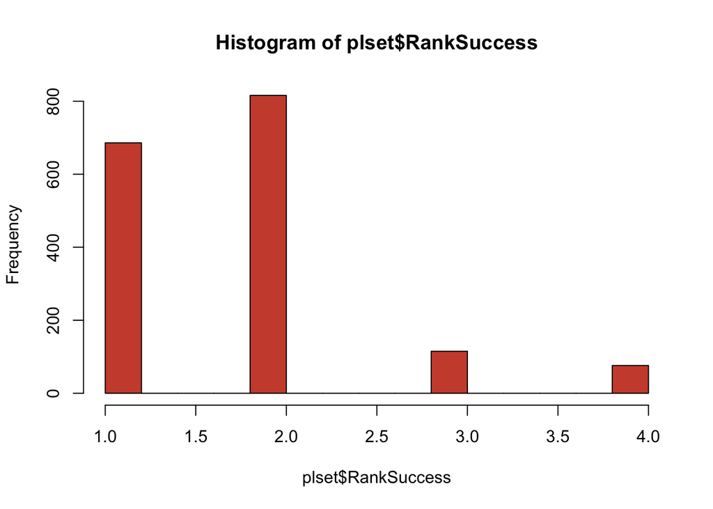

```r
hist(plset$RankSuccess, col = "tomato3")
```

```r
chisq.test(plset$RankLen, plset$RankSuccess)
```

```
##
##  Pearson's Chi-squared test
##
## data:  plset$RankLen and plset$RankSuccess
## X-squared = 16.292, df = 9, p-value = 0.06103
```

```r
cor(plset$RankLen, plset$RankSuccess)
```

```
## [1] 0.04081772
```

```r
cor.test(plset$RankLen, plset$RankSuccess)
```

```
##
##  Pearson's product-moment correlation
##
## data:  plset$RankLen and plset$RankSuccess
## t = 1.6799, df = 1691, p-value = 0.09316
## alternative hypothesis: true correlation is not equal to 0
## 95 percent confidence interval:
##  -0.006836028  0.088286486
## sample estimates:
##        cor
## 0.04081772
```

## TF-IDF для подзаголовков

(около 25000 слов)

```r
plset_tfidf <- plset %>%
  select(X, LeadBag, RankSuccess)

plset_tfidf <- plset_tfidf %>%
  mutate(LeadsTf = as.character(plset_tfidf$LeadBag)) %>%
  unnest_tokens(Word, LeadsTf) %>%
  count(X, RankSuccess, Word)

WordsTotal <- plset_tfidf %>%
  group_by(Word) %>%
  summarize(total = sum(n))

plset_tfidf <- left_join(plset_tfidf, WordsTotal)
plset_tfidf <- plset_tfidf %>%
  bind_tf_idf(Word, X, n)

plset_tfidf %>%
  arrange(desc(tf_idf))
```

```
## # A tibble: 25,571 x 8
##        X RankSuccess Word           n total    tf   idf tf_idf
##    <int>       <dbl> <chr>      <int> <int> <dbl> <dbl>  <dbl>
##  1  2282           1 подрастать     1     1  0.25  7.43   1.86
##  2  2282           1 народный       1     3  0.25  6.33   1.58
##  3  2282           1 традиция       1     3  0.25  6.33   1.58
##  4   306           2 кристина       2     5  0.25  6.04   1.51
##  5   236           4 душевая        1     1  0.2   7.43   1.49
##  6   704           2 конюшня        1     1  0.2   7.43   1.49
##  7   925           3 выборный       1     1  0.2   7.43   1.49
##  8   925           3 жилой          1     1  0.2   7.43   1.49
##  9   925           3 озеленение     1     1  0.2   7.43   1.49
## 10  1491           2 антибиотик     1     1  0.2   7.43   1.49
## # … with 25,561 more rows
```

```r
plset_tfidf %>%
  arrange(desc(-idf))
```

```
## # A tibble: 25,571 x 8
##        X RankSuccess Word        n total     tf   idf tf_idf
##    <int>       <dbl> <chr>   <int> <int>  <dbl> <dbl>  <dbl>
##  1     1           3 ребёнок     1   765 0.0667  1.03 0.0689
##  2     2           2 ребёнок     1   765 0.167   1.03 0.172
##  3    10           2 ребёнок     1   765 0.0667  1.03 0.0689
##  4    11           3 ребёнок     1   765 0.0588  1.03 0.0608
##  5    25           2 ребёнок     3   765 0.158   1.03 0.163
##  6    26           2 ребёнок     3   765 0.158   1.03 0.163
##  7    32           4 ребёнок     1   765 0.0556  1.03 0.0574
##  8    37           2 ребёнок     1   765 0.0909  1.03 0.0939
##  9    42           2 ребёнок     1   765 0.0588  1.03 0.0608
## 10    52           2 ребёнок     1   765 0.0556  1.03 0.0574
## # … with 25,561 more rows
```

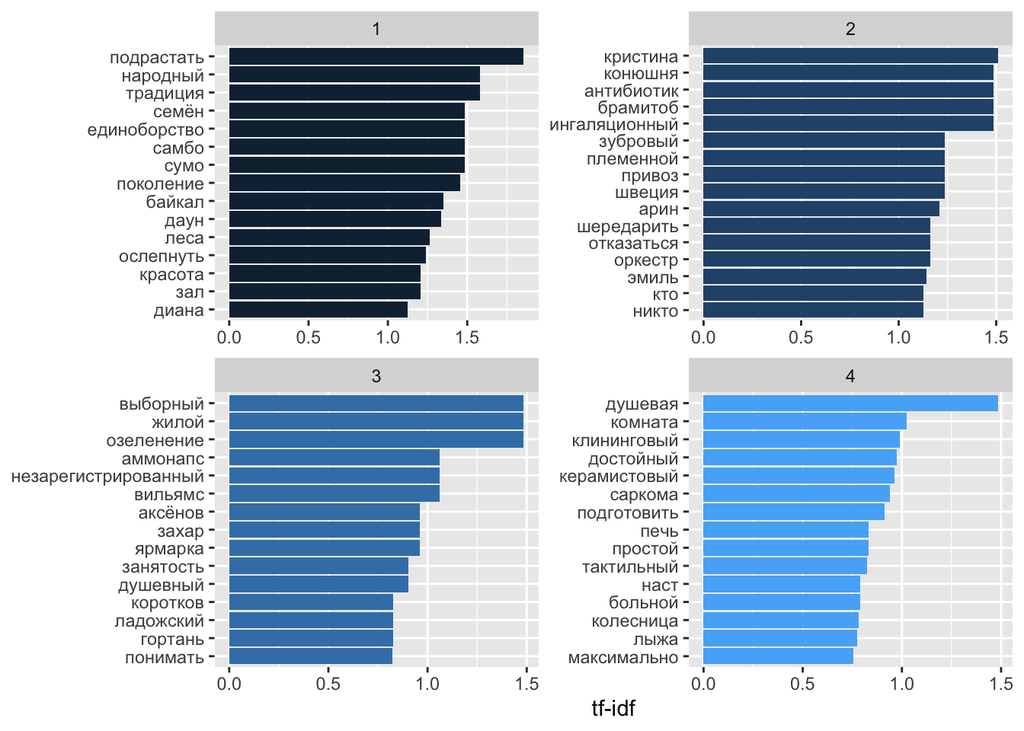

```r
plset_tfidf %>%
  arrange(desc(tf_idf)) %>%
    mutate(Word = factor(Word, levels = rev(unique(Word)))) %>%
    group_by(RankSuccess) %>%
    top_n(15) %>%
    ungroup() %>%
    ggplot(aes(Word, tf_idf, fill = RankSuccess)) +
    geom_col(show.legend = FALSE) +
    labs(x = NULL, y = "tf-idf") +
    facet_wrap(~RankSuccess, ncol = 2, scales = "free") +
    coord_flip()
```

## Вывод:

На данной коллекции текстов не выявлено закономерностей в:

  ```
    ¯\_(ツ)_/¯
  ```